# Math 253 Assignment 8

Jingjing Yang

12/1/2015

*Source file* ⇒ assignment_8.Rmd

# Theory Assignment

## 8.4.1 Draw an example of a partition and decision tree

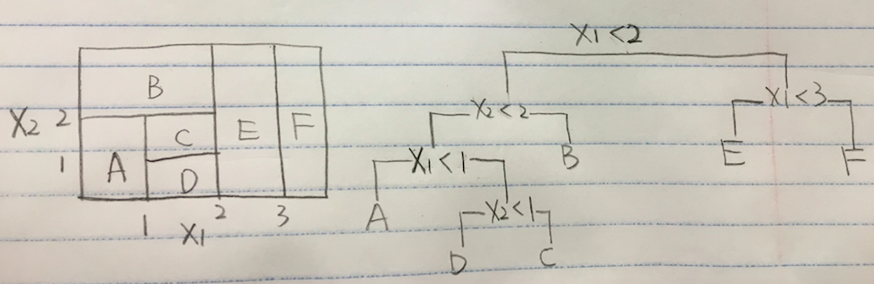

## 8.4.2 Boosting and additive model

In boosting, trees are grown sequentially: each tree is grown using information from previously grown trees. Each of these trees can be rather small, with just a few terminal nodes, and then combined together. When we set d – the number of splits in each tree – to be 1, it consists of only one split. It outputs an additive model since each term involves only a single variable.

## 8.4.3 The Gini index, classification error and cross_entropy

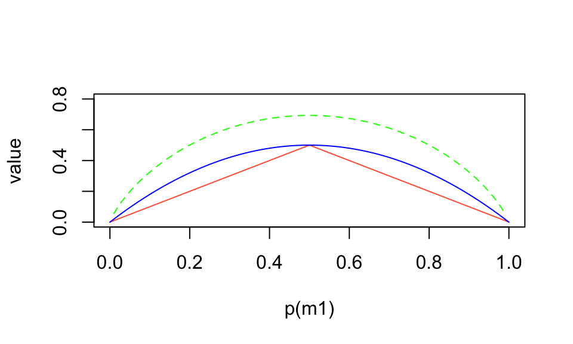

```r
#p(mk) represents the proportion of training observations in the mth region that are from the kth class.
class <- function(x){
  E = 1 - max(x, 1-x)
}
gini <- function(x){
  return(2*x*(1-x))
}
ent <- function(x){
  return(-((x*log(x))+((1-x)*log(1-x))))
}

err <- seq(0,1, by = 0.01)
class_err <- sapply(err, class)
gini_err <- sapply(err, gini)
ent_err <- sapply(err, ent)
df <- data.frame("Gini_Index" = gini_err, "Cross_entropy" = ent_err)
plot(err, class_err, type = "l", col = "tomato", xlab = "p(m1)", ylab = "value", ylim = c(0,0.8))
matlines(err, df, col = c("blue", "green"))
```

## 8.4.4

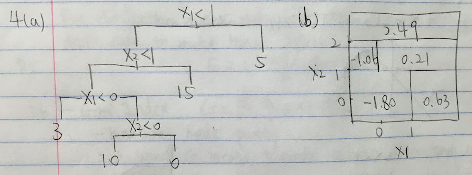

## 8.4.5

By the majority vote approach, the final classification is Red, because there are more “votes” for Red. By the average probability approach, the final classification is Green because the mean of x is less than 0.5.

```r
x=c(0.1, 0.15, 0.2, 0.2, 0.55, 0.6, 0.6, 0.65, 0.7, 0.75)
mean(x)
```

```
## [1] 0.45
```

# Programming Assignment

## 8.4.12 Applying boosting, bagging, and random forests and compare their performances

```r
library(tree)
library(mosaicData)
data(CPS85)
set.seed(100)
index <- sample(nrow(CPS85), nrow(CPS85) / 2)
CPS85$married <- ifelse(CPS85$married == "Married", 1, 0)
CPS85_training <- CPS85[index, ]
CPS85_test <- CPS85[-index, ]
```

### Logistic Regression

```r
logit_fit <- glm(married ~ . , data = CPS85_training, family = "binomial")
logit_prob <- predict(logit_fit, newdata = CPS85_test, type = "response")
logit_pred <- ifelse(logit_prob > 0.5, 1, 0)
table(CPS85_test$married, logit_pred)
```

```
##    logit_pred
##       0   1
##   0  35  49
##   1  40 143
```

The classification error for logistic regression is 0.3333.

### Bagging

```r
library (randomForest)
bag_fit <- randomForest(married ~ . , data = CPS85_training, mtry = length(names(CPS85)), importance =TRUE)
bag_prob <- predict(bag_fit, newdata = CPS85_test)
bag_pred <- ifelse(bag_prob > 0.5, 1, 0)
table(CPS85_test$married, bag_pred)
```

```
##    bag_pred
##       0   1
##   0  28  56
##   1  27 156
```

### Boosting

```r
library(gbm)
boost_fit <- gbm(married ~ . , data = CPS85_training, distribution = "bernoulli", n.trees = 1000)
boost_prob <- predict(boost_fit, newdata = CPS85_test, n.trees = 1000)
boost_pred <- ifelse(boost_prob > 0.5, 1, 0)
table(CPS85_test$married, boost_pred)
```

```
##    boost_pred
##       0   1
##   0  34  50
##   1  24 159
```

### Random Forests

```r
forest_fit <- randomForest(married ~ ., data =CPS85_training, mtry = 3)
forest_prob <- predict(forest_fit, newdata = CPS85_test)
forest_pred <- ifelse(forest_prob > 0.5, 1, 0)
table(CPS85_test$married, forest_pred)
```

```
##    forest_pred
##       0   1
##   0  29  55
##   1  24 159
```

### Conclusion

With this dataset, boosting performed best, closely followed by random forests.